# Attractive LLIN

###### *An attraction rate of 0.6 indicates that 60% of malaria vectors choose a human under an LLIN if presented against an unprotected human. The reference inert LLIN (panel A) has an attraction rate of 0.5 (no preference between LLIN protected or unprotected humans) and the reference deterrent LLIN (panel B) has an attraction rate of 0.36 (only 36% of the vectors choose an LLIN protected human against an unprotected human).*

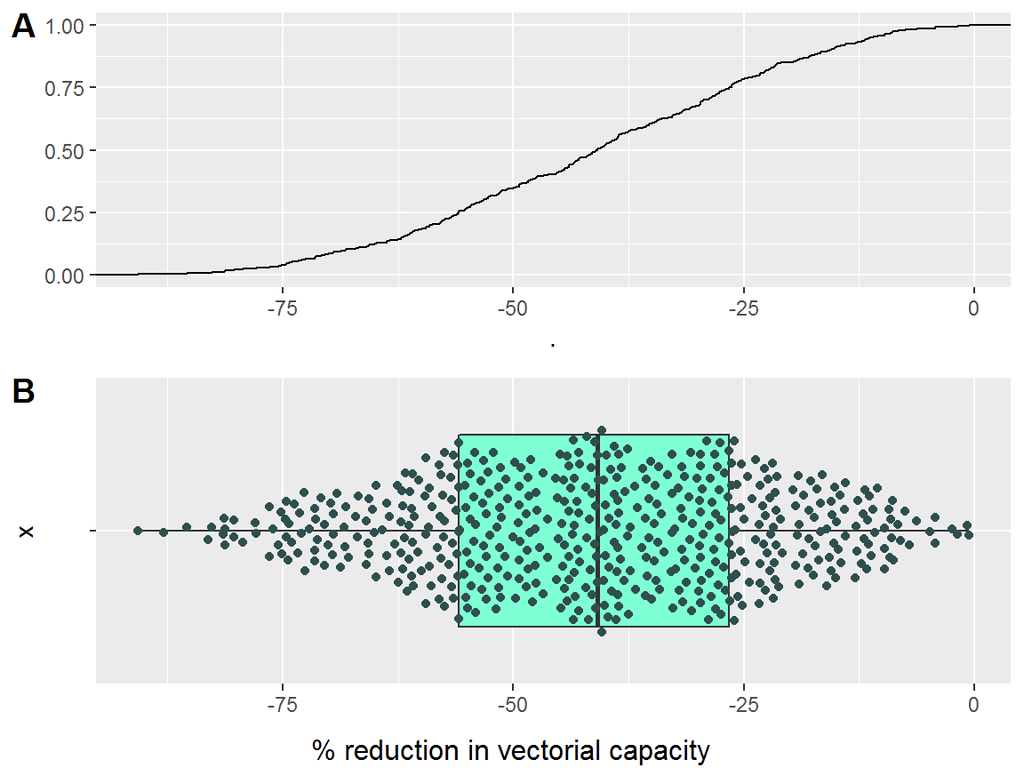

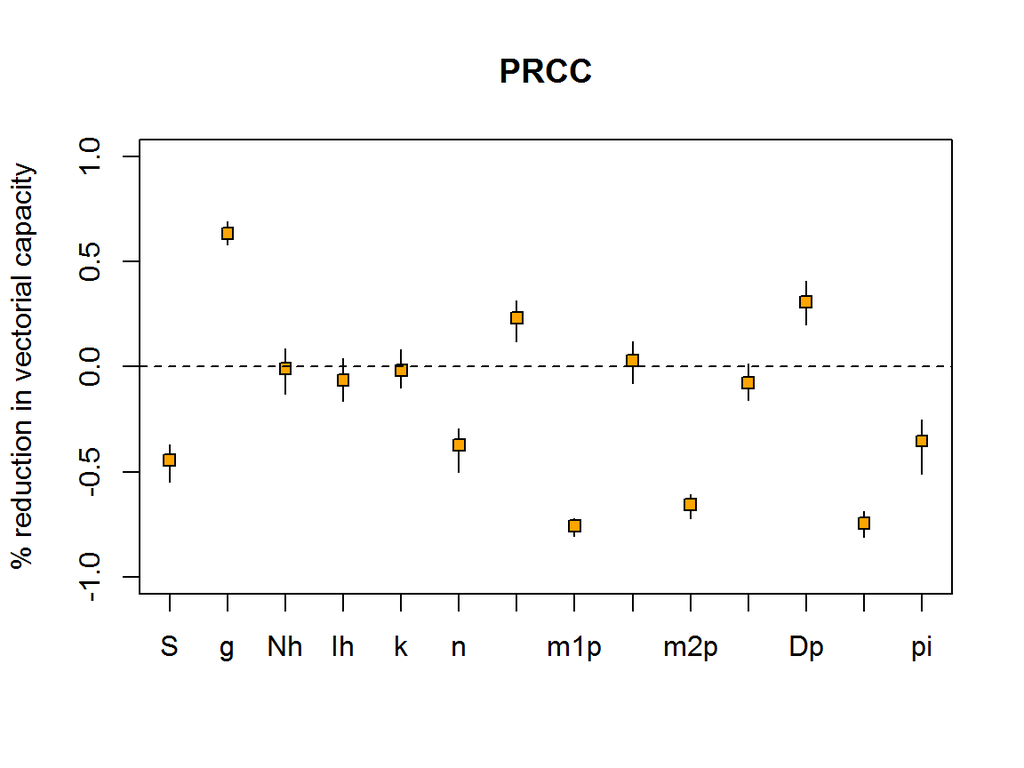

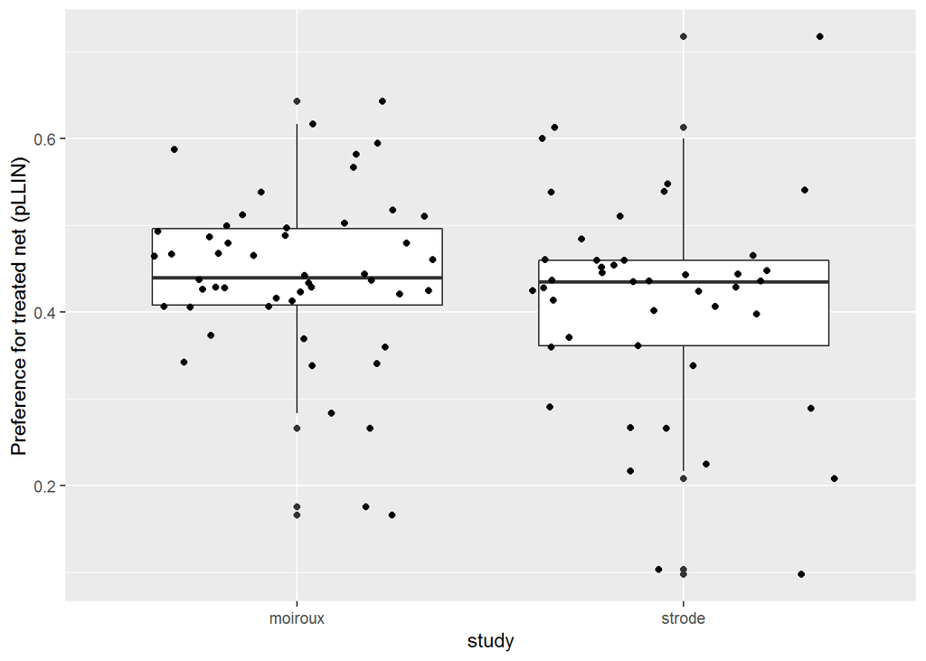

##### Supplementary Figure 1: Vector preference for insecticide treated nets measured in the fields through experimental hut trials.

###### *Data come from two studies [1,2]. Each point represent an ITN. There is 50 values coming from 9 EHT in the [1] data and 44 points coming from 13 EHT in the [2] data. Most values are below 0.5 indicating deterrence. About 25 % of the value are between 0.5 and 0.75 indicating attraction.*